# 2026-03-10-central-limit-theorem

## Central Limit Theorem

The *Central Limit Theorem* (CLT) states that a distribution of sample means approximates to normal as the sample size becomes large, no matter the population's original distribution. The sampling distribution's mean becomes equal to the population mean, and its variance equal to the population variance divided by the sample size.

$\bar{X}\sim\mathcal{N}(\mu,\frac{\sigma^2}{n})$

CLT is valid for the following conditions:

- The drawing of a sample from the population should be random.
- The drawing of a sample should be independent of each other.
- Sample size shouldn't be more than 10% of the population when sampling is done without replacement.
- Sample size should be sufficiently large (usually n > 30).
- CLT only holds for a population with finite variance.

```
Original Distribution
---------------------
mean: 9.983332657718599
var: 96.32410139368706
skewness: 1.8846614779416377

Sampling Distribution
---------------------
mean: 10.133291562715526
var: 1.672859764031172
var * n: 83.6429882015586
skewness: 0.1326626385379318
```

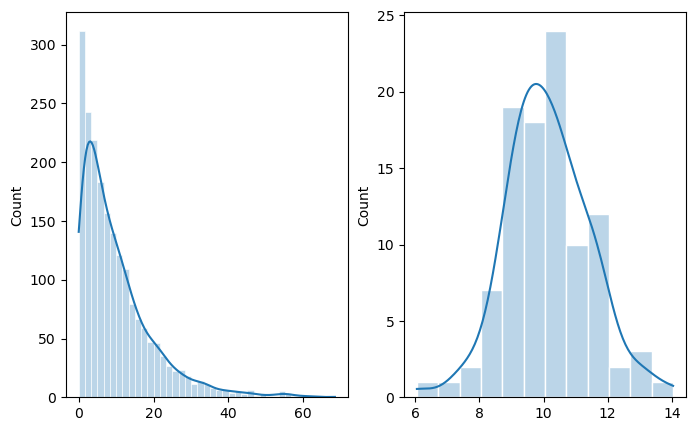

```python
import numpy as np
import seaborn as sns
import matplotlib.pyplot as plt
from scipy.stats import gaussian_kde
from scipy.stats import skew

def sample(x, n=50):
    copy = x.copy()
    np.random.shuffle(copy)
    return copy[:n]

plt.figure(figsize=(8, 5))

a = np.random.exponential(10, 2000)
plt.subplot(1,2,1)
sns.histplot(a, kde=True, edgecolor="white", alpha=0.3)

means = np.array([np.mean(sample(a)) for _ in range(100)])
plt.subplot(1,2,2)
sns.histplot(means, kde=True, edgecolor="white", alpha=0.3)

print(f"""Original Distribution
---------------------
mean: {np.mean(a)}
var: {np.var(a)}
skewness: {skew(a)}
""")

print(f"""Sampling Distribution
---------------------
mean: {np.mean(means)}
var: {np.var(means)}
var * n: {np.var(means) * 50}
skewness: {skew(means)}
""")
```

The standard deviation of the sampling distribution is also called the *Standard Error*.

Standard Error: $\sigma_{\bar{X}}=\frac{\sigma}{\sqrt{n}}$

```
np.float64(1.387977675567493)
```

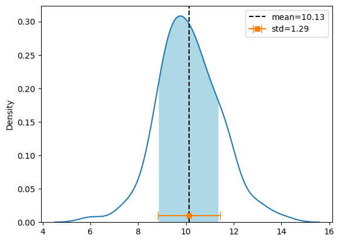

```python
def density_plot(data):
    graph = sns.kdeplot(data)
    plt.axvline(np.mean(data), c="black", linestyle="dashed", label=f"mean={np.mean(data):.2f}")
    kde = gaussian_kde(data)
    x = np.linspace(graph.get_xlim()[0], graph.get_xlim()[1], 100)
    y = kde(x)
    low, high = np.mean(data) - np.std(data), np.mean(data) + np.std(data)
    xy = [(x, y) for x, y in zip(x, y) if low <= x <= high]
    plt.fill_between([i[0] for i in xy], [i[1] for i in xy], color="lightblue")
    plt.errorbar(np.mean(data), 0.01, xerr=np.std(data), marker="s", capsize=5, label=f"std={np.std(data):.2f}")


density_plot(means)
plt.legend()
np.std(a) / np.sqrt(50)
```

#### Standardization:

$Z=\frac{\bar{X}-\mu}{\sigma/\sqrt{n}}$.

Standardization transforms a sample mean into a standard normal variable, facilitating statistical inference.

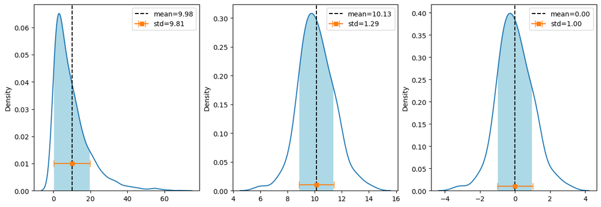

```python
plt.figure(figsize=(15, 5))

plt.subplot(1,3,1)
density_plot(a)
plt.legend()

plt.subplot(1,3,2)
density_plot(means)
plt.legend()

z = (means - np.mean(means)) / np.std(means)
plt.subplot(1,3,3)
density_plot(z)
plt.legend()
```

Note how the exponential distribution that we started with can be converted into a normal distribution, and from there into a standard normal distribution, just by drawing large enough samples.

### Conclusion

The Central Limit Theorem is crucial in statistics, as it allows the use of statistical methods that rely on a normal distribution, even when the data is not normally distributed. As long as the sample size is large enough, we can always assume a normal distribution of sample means.